# Лабораторна робота №1

Конько Ярослав, КН-24-1

## Тема

Основи роботи з Git. Налаштування Git-GitHub середовища

## Мета роботи

Швидкий старт для роботи із системою контроля версій (СКВ) Git та віддаленим репозиторієм GitHub.

## Хід роботи

### 1.Створення репозиторію на GitHub з відповідним змістом файлу README

[figure not shown]

### 2.Клонування віддаленого репозиторію на робочий комп’ютер

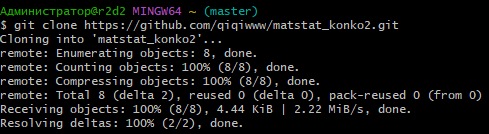

## Контрольні питання

### 1. Що таке система контроля версій (СКВ) і для чого вона призначена? У чому принципова відмінність СКВ SVN та GIT?

**Система контролю версій (СКВ)** - це програмне забезпечення для відстеження змін у файлах та координації роботи між кількома користувачами.

**Призначення СКВ:** - Зберігання історії змін файлів - Координація роботи команди - Можливість відкату до попередніх версій - Відстеження авторства змін

| Характеристика | SVN (Subversion) | Git |
| --- | --- | --- |
| Архітектура | Централізована | Розподілена |
| Швидкість | Повільніша | Швидша |
| Робота офлайн | Обмежена | Повна |
| Гілки | Важкі у використанні | Легкі та швидкі |

### 2. Що відбувається під час виконання команди git add?

Команда git add додає файли до **індексу** - проміжної області, де збираються зміни для подальшого коміту.

### 3. Що відбувається під час виконання команди git commit?

Команда git commit фіксує зміни, що знаходяться в індексі, у історії репозиторію.

### 4. Якою Git-командою виконується розміщення локальної копії Git-репозиторію проєкта на віддаленому, що знаходиться на GitHub?

Для розміщення локальної копії на GitHub використовується команда **git push**.